# Part II - (US Flights Review)

## by (Ugochukwu Okpoko)

## Investigation Overview

In this presentation, we will review the features that will help US residents make the best flight decisions with regards to Airlines, Day and time to schedule flights. We will also look at a way out for the worst Airline.

## Dataset Overview

There are 5.2 million US flights in the dataset scheduled between 2006 and 2008 from January to April. The dataset has 20 variables, some important features are; Day, Departure hour, Airline, and Distance.

## Distribution of Scheduled Flights

1% of the total flights booked were cancelled. For cancelled flights, 41% were due to Airlines while 39% were associated with Weather, about 20% were due to NAS, and less than 1% were due to Security.

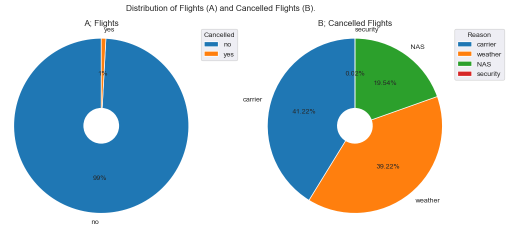

## What is the Relationship between Departure Hour and flights?

Flights were generally booked for takeoff during the day (between 6am and 1pm) than at night. The highest count (7.1%) of flights were booked for 6am. 5pm also saw a shoot in booked flights (6.8%). The least number of scheduled flights were booked for 3am.

Hours of the day with more flights, had more cancelled flights; more cancelled flights were recorded during the day.

It is advisable to scheduled flights for less busy hours to avoid flight cancellation; as departure hours with less than 150,000 scheduled flights saw the least cancelled flights

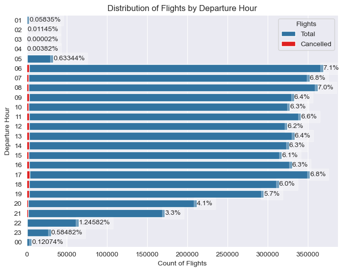

## What are the best and worst Airlines?

Southwest Airlines (about 800,000 flights) scheduled the most flights for the period, followed by Skywest Airlines (about 500,000 flights). Mesa Airlines is the 10th on the list with over 200,000 booked flights. Aloha Airlines had the least number of booked flights.

Some Airlines (Southwest > American Airways > Expressjet Airlines > American Eagle > Continental Air) have 100% record of flight completion.

Mesa Airlines (the worst Airline) had the highest number of cancelled flights; most (over 5000 flights) of which were due to Airlines (Carriers).

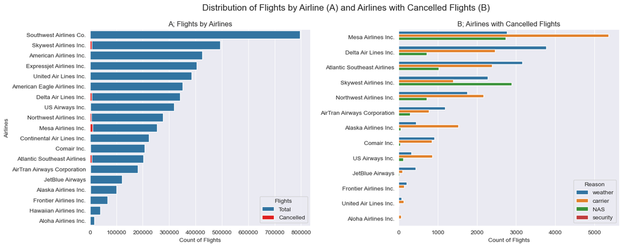

## Distribution of Flights by Year, Month and Day.

Flights for the period increased with year (2006 - 2008). Saturday and April had the least number of scheduled flights

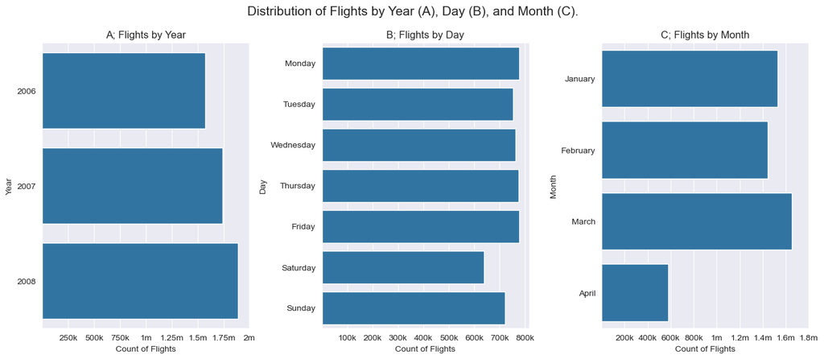

## Distribution of Cancelled Flights by Year, Month and Day.

Cancelled Flights tend to increase year-on-year. The least number of flights were cancelled in April and Saturday, respectively.

This corresponds with the number of scheduled flights; Year, Month, or Days with the least number of flights had the least number of cancelled flights.

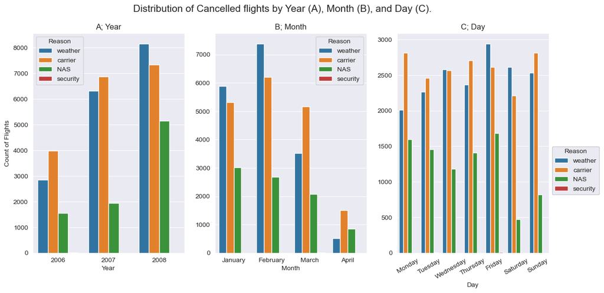

## Are there possible impacts of Distance over Flight completion?

The effects of Distance is not significant, although, shorter flights tend to get cancelled; as the median for cancelled flights is lesser than completed flights.

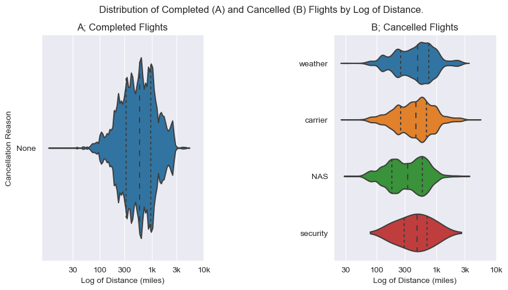

## What is the best time of the day to schedule flights?

For the period, 3am is the best time for any day (Monday - Sunday) to schedule flight as it recorded 100% flight completion.

Saturday had the least number of cancelled flights for any hour in any day.

[figure not shown]

## What are the preferred times to schedule flights with the worst Airlines?

The best flight periods are 2am - 5am, between Wednesday and Friday for the worst Airlines.

[figure not shown]

## Is it possible to schedule flights with Mesa Airlines on a Saturday?

For 100% Flight completion rate, Users are adviced to book flights on Saturdays with Mesa Airlines Inc., around 12am - 4am. Preferred airports are ordererd from least to best;

```
  1. 'Rapid City Regional'
  2. 'Wichita Mid-Continent'
  3. 'Seattle-Tacoma Intl',
  4. 'Louisville International-Standiford '
  5. 'Joe Foss ',
  6. 'Kent County International'
  7. 'Minneapolis-St Paul Intl'
  8. 'Sacramento International'
  9. 'Quad City'
  10. 'Daytona Beach International'.
```

[figure not shown]